# Mask Mandate Causal Impact Study

Colby Carter

10/31/2020

# Abstract

In this study, we use Google’s Causal Impact algorithm to estimate key Covid-19 outcome metrics in unobserved, counterfactual scenarios where select countrywide mask mandates *not* been employed. This analysis focuses on two European countries that adopted and largely complied with mask mandates several months into the pandemic: Germany with strong adoption by May (WSJ) and Switzerland requiring masks on public transit since July 6th. These countries are particularly useful because we can observe several nearby countries that both employed early and widespread adoption of masks early on (e.g. Italy) while others such as the Scandinavian countries did not. With the Causal Impact model, these other countries’ outcomes, plus social mobility data and other controls, can be used to predict the estimated non-mask adoption counterfactual. This does require strong assumptions, including that the mask “treatment” has no effect on the predictors. Therefore, this approach can help identify a difference where one may exist, but it does not fully isolate the treatment effect like a well-designed RCT would; Denmark conducted a large experiment on masks and Covid-19 that ended in August, but no publications have yet been willing to print.

# Data

The data for each model can include:

- 7-day rolling average of cases, tests, hospitalizations, ICU usage and deaths (where available) by country
- countries’ Apple social mobility scores for driving, transit and walking
- EU Global Dow Stock Index

Countries include:

- Italy (early mask adoption)
- Sweden (no masks)
- Denmark (no masks)
- Norway (no masks)

The data begin on January 24, 2020 and go through October 25. Most measured variables do not produce values until roughly March 1. Note that toward the end of the period in October, many European countries experience rising case levels that appear to exceed earlier periods, though this metric does not control for testing and unobserved asymptomatic cases.

```
##        date day week sui_cases sui_deaths  sui_tests sui_drive sui_transit
## 1 1/24/2020   1    4         0          0  0.4285714  109.4257    104.2271
## 2 1/25/2020   2    4         0          0  1.0000000  110.3414    104.2900
## 3 1/26/2020   3    5         0          0  1.1666667  110.4914    103.6829
## 4 1/27/2020   4    5         0          0  3.3333333  110.0286    103.2157
## 5 1/28/2020   5    5         0          0  6.0000000  109.5743    102.7186
## 6 1/29/2020   6    5         0          0 10.8333333  109.4286    102.3300
##   sui_walk ger_cases ger_hosp ger_deaths ger_drive ger_transit ger_walk
## 1 111.9086 0.0000000        0          0  104.9771    104.9457 107.8814
## 2 112.3686 0.0000000        0          0  104.8629    105.0700 107.5543
## 3 111.9729 0.0000000        0          0  104.6414    104.6514 107.3143
## 4 111.3571 0.0000000        0          0  104.8400    104.9543 107.2871
## 5 109.2457 0.1428571        0          0  105.1686    104.9286 106.7329
## 6 107.9100 0.5714286        0          0  105.1957    104.8543 106.6271
##   den_cases den_hosp den_icu den_deaths den_tests swe_cases swe_deaths
```

[output cut: 34 more lines]

Note: remove France–it’s confounding due to mask adoption midway

Germany = 5/1 = 99 Switzerland = 7/1 = 160

#### Data periods

1 = 1/24 38 = 3/1 252 = 10/1

# Switzerland

We begin with estimating outcomes in Switzerland, which enacted a mask mandate for public transportation plus indoors in key public spaces (e.g. grocery stores) in two populated regions.

```
##   sui_cases  sui_tests sui_drive sui_transit sui_walk den_cases den_hosp
## 1         0  0.4285714  109.4257    104.2271 111.9086         0        0
## 2         0  1.0000000  110.3414    104.2900 112.3686         0        0
## 3         0  1.1666667  110.4914    103.6829 111.9729         0        0
## 4         0  3.3333333  110.0286    103.2157 111.3571         0        0
## 5         0  6.0000000  109.5743    102.7186 109.2457         0        0
## 6         0 10.8333333  109.4286    102.3300 107.9100         0        0
##   den_icu den_deaths den_tests swe_cases swe_deaths swe_drive swe_transit
## 1       0          0 0.0000000         0          0 100.72143    108.1786
## 2       0          0 0.0000000         0          0  99.98714    109.7571
## 3       0          0 0.0000000         0          0  99.19429    109.8400
## 4       0          0 0.1666667         0          0  98.70143    109.8957
## 5       0          0 0.2000000         0          0  98.46571    110.3714
## 6       0          0 0.4000000         0          0  98.47143    110.1486
##   swe_walk nor_cases nor_hosp nor_deaths nor_tests nor_drive nor_transit
```

[output cut: 20 more lines]

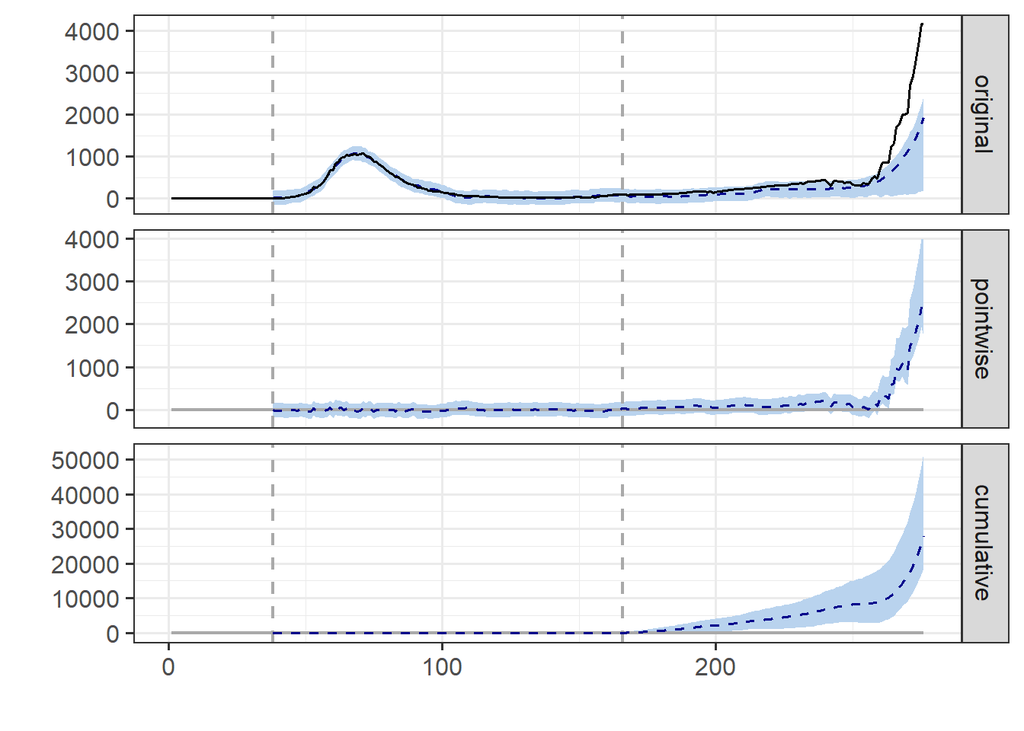

```r
# ignore pre-virus period up to 3/1
covidStart <- 38

lag <- 7  # lag mask start
pre.Swiss2 <- c(covidStart, 159+lag)
post.Swiss2 <- c(160+lag, 276)

impactSwiss2 <- CausalImpact(swissDF, pre.Swiss2, post.Swiss2)
plot(impactSwiss2)
```

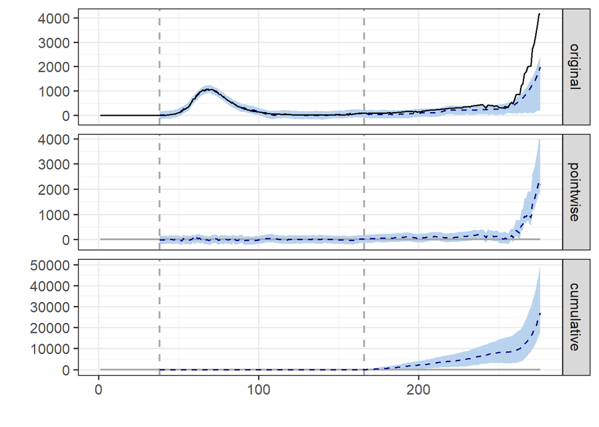

```r
# without Swiss tests and mobility scores
swiss_excl_soc <- select(swissDF, -c(sui_tests, sui_drive, sui_transit, sui_walk))

impactSwiss3.2 <- CausalImpact(swiss_excl_soc, pre.Swiss2, post.Swiss2)
plot(impactSwiss3.2)
```

More important than confirmed cases, we also have Swiss deaths attributed to Covid-19, which are less noisy, or incomplete, due to (lack of early) testing. Here we observe a counterfacture time series indistinguishable from the true, masked level, which stayed close to zero daily deaths after the original March surge.

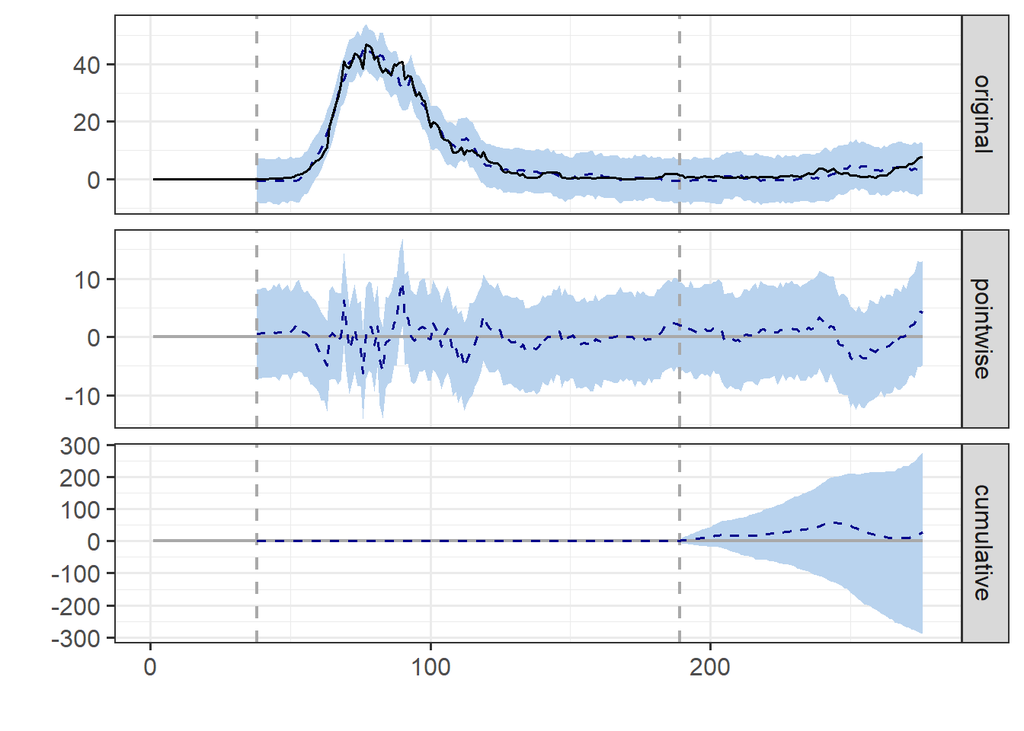

```r
lag6 <- 30  # lag mask start
pre.Swiss6 <- c(covidStart, 159+lag6)
post.Swiss6 <- c(160+lag6, 276)

impactSwiss6 <- CausalImpact(swissDeaths, pre.Swiss6, post.Swiss6)
plot(impactSwiss6)
```

# Germany

The early European Covid-19 model of Germany offers a potentially useful test subject wherein the country was a fairly early mask adopter on May 1 *following* the initial European surge that hit many neighboring countries (e.g. Italy) but well before the fall return.

```
##   ger_cases ger_drive ger_transit ger_walk den_cases den_hosp den_icu
## 1 0.0000000  104.9771    104.9457 107.8814         0        0       0
## 2 0.0000000  104.8629    105.0700 107.5543         0        0       0
## 3 0.0000000  104.6414    104.6514 107.3143         0        0       0
## 4 0.0000000  104.8400    104.9543 107.2871         0        0       0
## 5 0.1428571  105.1686    104.9286 106.7329         0        0       0
## 6 0.5714286  105.1957    104.8543 106.6271         0        0       0
##   den_deaths den_tests swe_cases swe_deaths swe_drive swe_transit swe_walk
## 1          0 0.0000000         0          0 100.72143    108.1786 116.5000
## 2          0 0.0000000         0          0  99.98714    109.7571 119.7229
## 3          0 0.0000000         0          0  99.19429    109.8400 118.7343
## 4          0 0.1666667         0          0  98.70143    109.8957 117.7971
## 5          0 0.2000000         0          0  98.46571    110.3714 116.6914
## 6          0 0.4000000         0          0  98.47143    110.1486 116.3200
##   nor_cases nor_hosp nor_deaths nor_tests nor_drive nor_transit nor_walk
```

[output cut: 20 more lines]

Similarly to Swiss cases but with fewer anticipated late cases, much of the steady case volume follows the estimated maskless scenario closely, but not once the fall case volume begins to climb rapidly. Based on the experiences of the surrounding fully masked (Italy) and non-masked Scandinavian countries, which include late fall surges, this model still does not expect a late case surge in the maskless counterfactual, surprisingly. The model suggests cases therefore rise higher than they would have, say, like the Scandinavian countries, however this again does not match intuition unless behavior became much more interactive in Germany while still complying with mask-wearing. Keep in mind, these models do factor in social mobility of these countries, which like test frequency, could be influenced by the masking intervention (i.e. more socializing with heightened sense of security.)

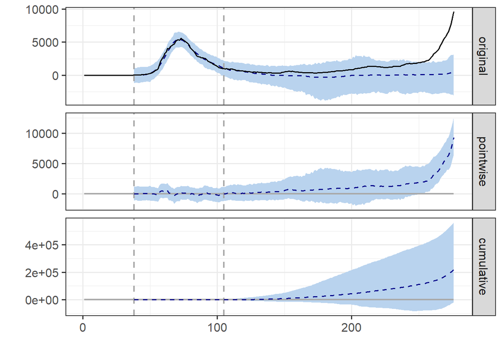

```r
impactGermany <- CausalImpact(germanyDF, pre.Germany, post.Germany)
plot(impactGermany)
```

A better metric, less reliant on testing, is hospitalizations, which Germany reports once weekly. Here we impute a smoothed daily hospitalization count and use similar predictors.

```r
# Germany HOSPITALIZATIONS
# note: this metric is weekly, and thus a smoothed value; must be cut off at 10/10
germanyHosp <- cbind(countryDF$ger_hosp, select(countryDF, -c(date, day, week,
                                                             ger_cases, ger_hosp, ger_deaths,
                                                             sui_cases, sui_deaths, sui_tests, sui_transit, sui_walk, sui_drive,
                                                             fra_cases, fra_hosp, fra_icu, fra_deaths, fra_drive, fra_transit, fra_walk
                                                             # us_cases, us_tests
                                                             )))

names(germanyHosp)[names(germanyHosp)=="countryDF$ger_hosp"] <- "ger_hosp"

germHospCutoff <- 261  # 10/10 hospital cutoff
germanyHosp <- germanyHosp[1:germHospCutoff,]

head(germanyHosp)
```

```
##   ger_hosp ger_drive ger_transit ger_walk den_cases den_hosp den_icu den_deaths
## 1        0  104.9771    104.9457 107.8814         0        0       0          0
## 2        0  104.8629    105.0700 107.5543         0        0       0          0
## 3        0  104.6414    104.6514 107.3143         0        0       0          0
## 4        0  104.8400    104.9543 107.2871         0        0       0          0
## 5        0  105.1686    104.9286 106.7329         0        0       0          0
## 6        0  105.1957    104.8543 106.6271         0        0       0          0
##   den_tests swe_cases swe_deaths swe_drive swe_transit swe_walk nor_cases
## 1 0.0000000         0          0 100.72143    108.1786 116.5000         0
## 2 0.0000000         0          0  99.98714    109.7571 119.7229         0
## 3 0.0000000         0          0  99.19429    109.8400 118.7343         0
## 4 0.1666667         0          0  98.70143    109.8957 117.7971         0
## 5 0.2000000         0          0  98.46571    110.3714 116.6914         0
## 6 0.4000000         0          0  98.47143    110.1486 116.3200         0
##   nor_hosp nor_deaths nor_tests nor_drive nor_transit nor_walk   eu_dow
```

[output cut: 20 more lines]

With this model, we see no discernible difference between the observed and estimated maskless hospitalization counts, which are steady and low throughout the period.

```r
lag2 <- 10  # typical days to hospitalization from initial infection
pre.Germany2 <- c(covidStart, 98+lag2)
post.Germany2 <- c(99+lag2, 276)

impactGermany2 <- CausalImpact(germanyHosp, pre.Germany2, post.Germany2)
```

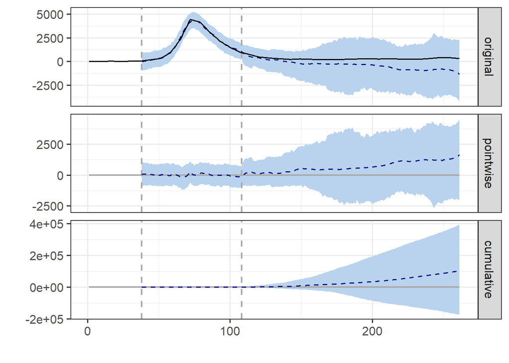

[output not shown]

```r
plot(impactGermany2)
```

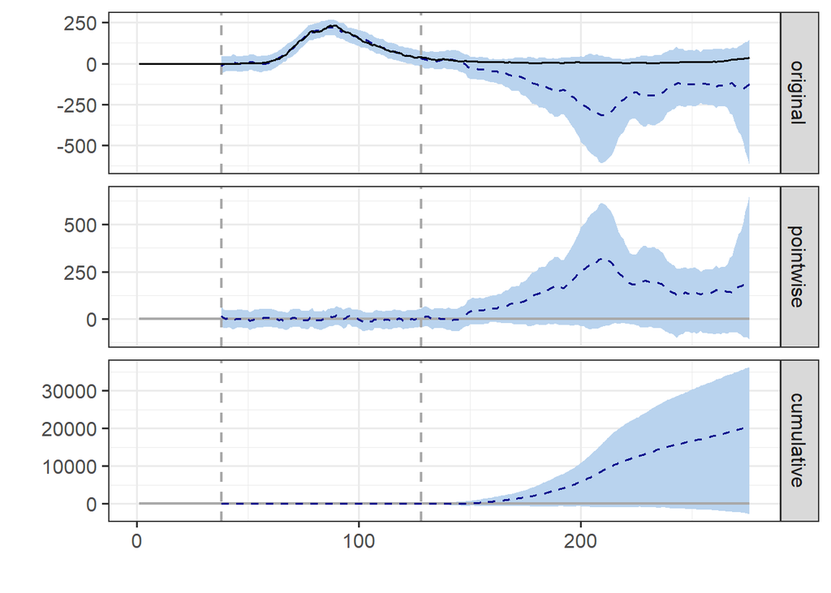

```r
lag3 <- 30  # typical days to hospitalization from initial infection
pre.Germany3 <- c(covidStart, 98+lag3)
post.Germany3 <- c(99+lag3, 276)

impactGermany3 <- CausalImpact(germanyDeaths, pre.Germany3, post.Germany3)
plot(impactGermany3)
```

# Conclusion

While direct conclusions cannot be drawn from this analysis due to the confoundedness of mask mandates, societal attitudes and adoption, and the seasonal nature of coronavirus spread, Causal Impact offers an attempt at controlling for independent trend variables and predict outcomes but-for a treatment–in this case, government mandated mask-wearing. This selection of control variables where mask-wearing was not heavily adopted suggests no effect on several covid outcomes, or even a worsening–a hypothesis could be a false sense of protection afforded by the intervention–however, this algorithm is likely insufficient, like many observational or even randomized studies (Denmark without double-blind option), to prove a meaningful causal effect.

## Sources

Apple Mobility Trends Reports, https://covid19.apple.com/mobility

Covid-19 Explorer, WHO, https://worldhealthorg.shinyapps.io/covid/

Global Dow EU, https://www.investing.com/indices/the-global-dow-eur-historical-data

“Masks Could Help Stop Coronavirus. So Why Are They Still Controversial?”, WSJ, 29 June 2020, https://www.wsj.com/articles/masks-could-help-stop-coronavirus-so-why-are-they-still-controversial-11593336601

“Coronavirus: the situation in Switzerland”, SwissInfo, 11 November 2020, https://www.swissinfo.ch/eng/society/covid-19_coronavirus--the-situation-in-switzerland/45592192